# Final

ML Final Project

Import the required libraries

```python
import pandas as pd
import nltk
nltk.download('stopwords')
nltk.download('punkt')
from nltk.corpus import stopwords
from nltk.tokenize import word_tokenize
from collections import Counter
import matplotlib.pyplot as plt
import seaborn as sns
import string
import re
import matplotlib.pyplot as plt
```

```python
!pip install contractions
```

Load the dataset

```python
df = pd.read_csv('/content/drive/MyDrive/Final ML/22204097.csv')
```

Here, we define our function with which we shall preprocess and tokenize our text

```python
def preprocess_and_tokenize(data):
    stop_words = set(stopwords.words('english'))
    word_tokens = word_tokenize(data)
    filtered_text = [word for word in word_tokens if word.casefold() not in stop_words]
    return filtered_text
```

Analyze the most commonly occuring words for each category

```python
def analyze():
  for category in df['category'].unique():
      words = []
      for row in df[df['category'] == category][['headline', 'short_description']].values:
          words.extend(preprocess_and_tokenize(" ".join(row)))
      most_common_terms = Counter(words).most_common(10)
      print(f"For {category}, the most common terms are: {most_common_terms}")
#analyze()
```

```python
df['headline'] = df['headline'].fillna('')
df['short_description'] = df['short_description'].fillna('')
```

Remove any rows with missing text

```python
df = df.dropna(subset=['headline', 'short_description'])
```

Attempt to Analyze the most commonly occuring words for each category again

```python
analyze()
```

```
For PARENTING, the most common terms are: [(',', 10119), ('.', 8319), ("'s", 2784), (':', 1857), ('?', 1668), ("n't", 1320), ('``', 1162), ('(', 993), (')', 949), ("''", 937)]
For WORLDPOST, the most common terms are: [(',', 2309), ('.', 1909), ("'s", 821), (':', 441), ('?', 219), ("''", 206), ('``', 205), ('--', 203), ("'", 160), ('U.S.', 140)]
For nan, the most common terms are: []
```

Our output doesn't seem to actually align with obtaining the most common words. This seems to be a side effect of tokenization. Let's revise the preprocessing function to exclude punctuation by using 'string.punctuation'.

```python
def preprocess_and_tokenize(data):
    stop_words = set(stopwords.words('english'))
    stop_words.update(set(string.punctuation))
    word_tokens = word_tokenize(data)
    filtered_text = [word for word in word_tokens if word.casefold() not in stop_words]
    return filtered_text
```

Rerun the analysis

```python
analyze()
```

```
For PARENTING, the most common terms are: [("'s", 2784), ("n't", 1320), ('``', 1162), ("''", 937), ('--', 894), ('children', 771), ('Kids', 753), ('kids', 700), ('child', 538), ('parents', 527)]
For WORLDPOST, the most common terms are: [("'s", 821), ("''", 206), ('``', 205), ('--', 203), ('U.S.', 140), ('ISIS', 135), ('Iran', 121), ('China', 121), ('Israel', 117), ('world', 115)]
For nan, the most common terms are: []
```

While relatively better, our output is still including unwanted strings such as "'s", "n't" etc We shall use the 're' module to remove non-alphanumeric characters from our strings. We shall then use 'contractions' library. This is so we can split contractions into separate words.

```python
def preprocess_and_tokenize(data):
    stop_words = set(stopwords.words('english'))
    stop_words.update(set(string.punctuation))
    expanded_words = []
    for word in data.split():
        expanded_words.append(contractions.fix(word))
    data = ' '.join(expanded_words)
    data = re.sub(r'\W', ' ', data)
    data = re.sub(r'\s+', ' ', data)
    word_tokens = word_tokenize(data)
    filtered_text = [word for word in word_tokens if word.casefold() not in stop_words]
    return filtered_text
```

An example of what is going on in this function: "don't" is converted to "do not". Run analyze() again

```python
analyze()
```

```
For PARENTING, the most common terms are: [('children', 772), ('Kids', 757), ('kids', 703), ('child', 549), ('time', 540), ('one', 538), ('parents', 532), ('like', 449), ('would', 425), ('Parents', 420)]
For WORLDPOST, the most common terms are: [('ISIS', 141), ('China', 127), ('Israel', 127), ('Iran', 124), ('world', 115), ('World', 113), ('one', 103), ('Europe', 92), ('Ukraine', 91), ('Syria', 90)]
For nan, the most common terms are: []
```

This output is much more representative of the answer we are looking for: the most occuring words in each category.

Let's make a visual representation of our findings

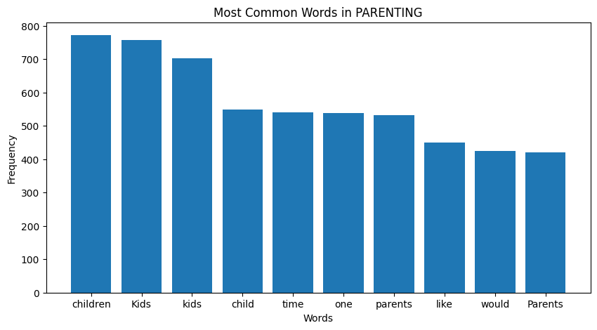

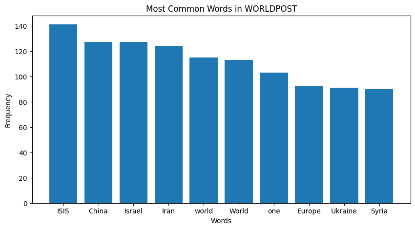

```python
def plot_common_words(category):
    words = []
    for row in df[df['category'] == category][['headline', 'short_description']].values:
        words.extend(preprocess_and_tokenize(" ".join(row)))
    most_common_terms = dict(Counter(words).most_common(10))

    plt.figure(figsize=(10, 5))
    plt.bar(most_common_terms.keys(), most_common_terms.values())
    plt.title(f'Most Common Words in {category}')
    plt.xlabel('Words')
    plt.ylabel('Frequency')
    plt.show()

for category in df['category'].unique():
    if pd.isna(category):
        continue
    plot_common_words(category)
```

Let's analyze some other features and their relationships with labels. For starters, we could analyze the length of the headlines and the descriptions for each category.

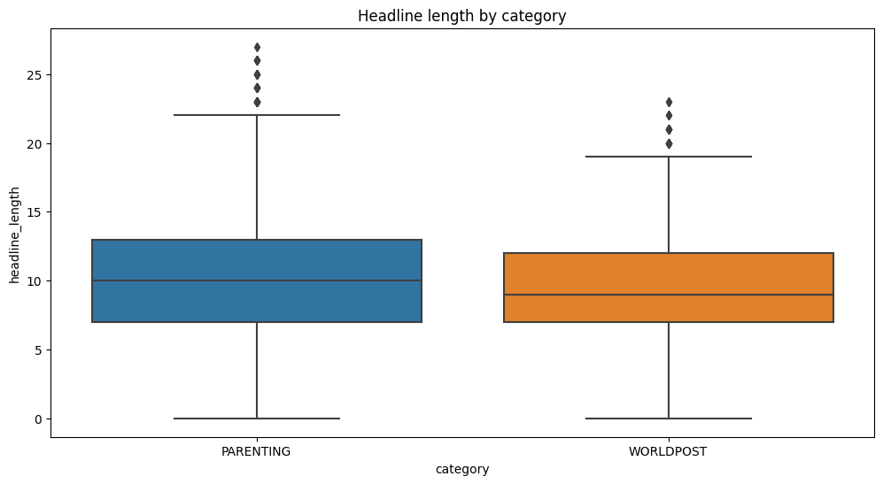

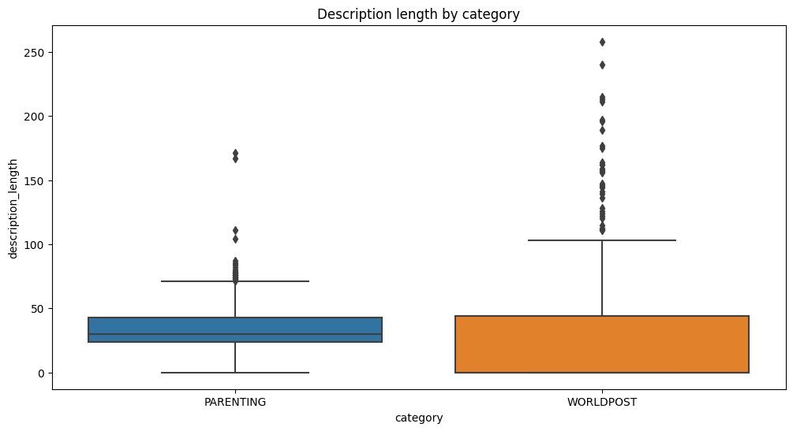

```python
df['headline_length'] = df['headline'].apply(lambda x: len(word_tokenize(x)))
df['description_length'] = df['short_description'].apply(lambda x: len(word_tokenize(x)))

plt.figure(figsize=(12,6))
sns.boxplot(data=df, x='category', y='headline_length')
plt.title('Headline length by category')
plt.show()

plt.figure(figsize=(12,6))
sns.boxplot(data=df, x='category', y='description_length')
plt.title('Description length by category')
plt.show()
```

Let's perform a date-time analysis to see if we can discover any interesting insights.

Trend Analysis to see if there are any noticeable trends.

```
array([<Axes: xlabel='date'>, <Axes: xlabel='date'>], dtype=object)
```

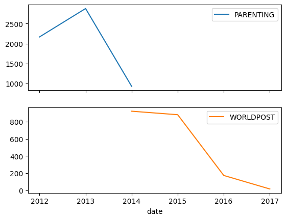

```python
df['date'] = pd.to_datetime(df['date'])
df.groupby([df.date.dt.year, 'category']).size().unstack().plot(kind='line', subplots=True)
```

Seasonality Analysis to see if we can look for patterns that recur at regular intervals.

```
array([<Axes: xlabel='date'>, <Axes: xlabel='date'>], dtype=object)
```

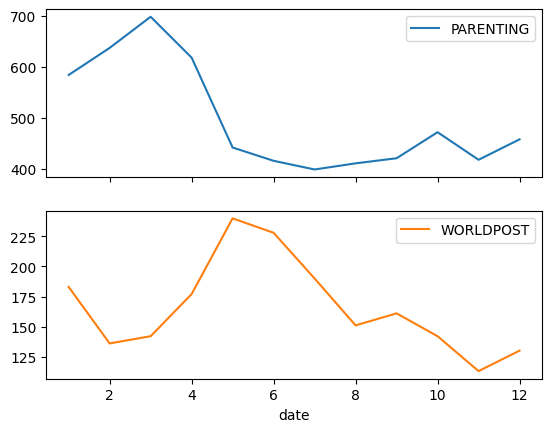

```python
df.groupby([df.date.dt.month, 'category']).size().unstack().plot(kind='line', subplots=True)
```

**TASK 2**

Splitting the dataset into training, development and test sets. We shall be looking to split our data into 60% for training, 20% for validation and 20% for testing.

```python
from sklearn.model_selection import train_test_split

df = df.dropna()

# Split into training and temp
df_train, df_temp = train_test_split(df, test_size=0.4, random_state=42, stratify=df['category'])

# Split temp into validation and test
df_valid, df_test = train_test_split(df_temp, test_size=0.5, random_state=42, stratify=df_temp['category'])

# Save the datasets into csv files
df_train.to_csv('train.csv', index=False)
df_valid.to_csv('valid.csv', index=False)
df_test.to_csv('test.csv', index=False)
```

```python
testes = pd.read_csv('test.csv')
testes.head()
```

|  | Unnamed: 0 | category | headline | authors | link | short_description | date | headline_length | description_length |
| --- | --- | --- | --- | --- | --- | --- | --- | --- | --- |
| 0 | 5546 | PARENTING | 'We're Losing Our Little Boy': One Family's He... | Joy Resmovits | https://www.huffingtonpost.com/entry/public-sc... | By the time Max turned 2, his speech delay bec... | 2013-11-24 | 18 | 23 |
| 1 | 918 | PARENTING | The Part of Parenting We're Too Scared to Talk... | Wendy Bradford, Contributor\nWriter and Blogge... | https://www.huffingtonpost.com/entry/the-part-... | No one is perfect. We all lose it sometimes. B... | 2014-01-07 | 11 | 25 |
| 2 | 3416 | PARENTING | First Grade and My First Tears | Abbie Rumbach, Contributor\nBlogger, "The Kids... | https://www.huffingtonpost.com/entry/first-gra... | Why wasn't I crying with the other moms on the... | 2012-08-24 | 6 | 33 |
| 3 | 2947 | PARENTING | Who Are The 'Real' Parents? An Adoptive Dad's ... | David Valdes Greenwood, Guest Writer\nDad, Pla... | https://www.huffingtonpost.com/entry/adoptive-... | Whatever it is that keeps our daughter's mothe... | 2012-05-23 | 12 | 34 |
| 4 | 1495 | PARENTING | 5 Parenting Strategies That Work | Delia Lloyd, Contributor\nAmerican blogger bas... | https://www.huffingtonpost.com/entry/parenting... | This week I thought I'd share some new (but re... | 2012-02-08 | 5 | 25 |

We might need to remove NaN values.

```python
df = df.dropna(subset=['category'])
```

```python
# Split into training and tempe
df_train, df_temp = train_test_split(df, test_size=0.4, random_state=42, stratify=df['category'],shuffle=True)

# Split temp into valid and test
df_valid, df_test = train_test_split(df_temp, test_size=0.5, random_state=42, stratify=df_temp['category'],shuffle=True)

# Save the datasets into csv files
df_train.to_csv('train.csv', index=False)
df_valid.to_csv('valid.csv', index=False)
df_test.to_csv('test.csv', index=False)
```

```python
df_train['headline'] = df_train['headline'].fillna('')
df_train['short_description'] = df_train['short_description'].fillna('')

df_valid['headline'] = df_valid['headline'].fillna('')
df_valid['short_description'] = df_valid['short_description'].fillna('')
```

We can now load data and apply preprocessing steps

```python
import pandas as pd
from sklearn.feature_extraction.text import TfidfVectorizer

# Load the training and validation datasets
df_train = pd.read_csv('train.csv')
df_valid = pd.read_csv('valid.csv')
df_train['headline'] = df_train['headline'].fillna('')
df_train['short_description'] = df_train['short_description'].fillna('')

df_valid['headline'] = df_valid['headline'].fillna('')
df_valid['short_description'] = df_valid['short_description'].fillna('')

'''
# Initialize a TF-IDF Vectorizer
vectorizer = TfidfVectorizer(lowercase=True, stop_words='english')

# Fit and transform the training data
X_train = vectorizer.fit_transform(df_train['headline'] + ' ' + df_train['short_description'])

# Transform the validation data
X_valid = vectorizer.transform(df_valid['headline'] + ' ' + df_valid['short_description'])
'''
# Create a TF-IDF Vectorizer instance
vectorizer = TfidfVectorizer(ngram_range=(1, 2),
                             stop_words='english',
                             max_df=0.5,
                             min_df=2,
                             max_features=5000)

# Fit and transform the training data
X_train = vectorizer.fit_transform(df_train['headline'] + ' ' + df_train['short_description'])

# Transform the validation data
X_valid = vectorizer.transform(df_valid['headline'] + ' ' + df_valid['short_description'])

# Get the labels
y_train = df_train['category']
y_valid = df_valid['category']
```

```python
y_test = df_test['category']
```

Building binary classification models

```python
from sklearn.linear_model import LogisticRegression
from sklearn.svm import LinearSVC

# Initialize the classifiers
clf1 = LogisticRegression(random_state=42)
clf2 = LinearSVC(random_state=42)

# Fit the classifiers
clf1.fit(X_train, y_train)
clf2.fit(X_train, y_train)

# Predict the labels of the validation set
y_pred1 = clf1.predict(X_valid)
y_pred2 = clf2.predict(X_valid)
```

Building a classifier using deep learning

```python
pip install tensorflow
```

```python
import os
os.environ['CUDA_VISIBLE_DEVICES'] = '-1'
```

```python
import tensorflow as tf
print(tf.__version__)
```

```
2.13.0
```

```python
!pip install --upgrade tensorflow
```

```python
from sklearn.preprocessing import LabelEncoder

# create an encoder
le = LabelEncoder()

# fit and transform y_train with the encoder
y_train = le.fit_transform(y_train)

# transform y_valid with the encoder
y_valid = le.transform(y_valid)
```

```python
y_test = le.transform(y_test)
```

```python
from tensorflow.keras.preprocessing.text import Tokenizer
from tensorflow.keras.preprocessing.sequence import pad_sequences
from tensorflow.keras.models import Sequential
from tensorflow.keras.layers import Dense, Embedding, LSTM

y_train = y_train.astype(float)
y_valid = y_valid.astype(float)


# Tokenize the texts
tokenizer = Tokenizer(num_words=5000)
tokenizer.fit_on_texts(df_train['headline'] + ' ' + df_train['short_description'])

X_train = tokenizer.texts_to_sequences(df_train['headline'] + ' ' + df_train['short_description'])
X_valid = tokenizer.texts_to_sequences(df_valid['headline'] + ' ' + df_valid['short_description'])

# Pad the sequences
X_train = pad_sequences(X_train, maxlen=100)
X_valid = pad_sequences(X_valid, maxlen=100)

# Build the model
model = Sequential()
model.add(Embedding(5000, 64))
model.add(LSTM(64, dropout=0.2, recurrent_dropout=0.2))
model.add(Dense(1, activation='sigmoid'))

# Compile the model
model.compile(loss='binary_crossentropy', optimizer='adam', metrics=['accuracy'])

# Train the model
model.fit(X_train, y_train, batch_size=32, epochs=10, validation_data=(X_valid, y_valid))

# Save the model
model.save('text_classifier.h5')
```

```python
X_test = tokenizer.texts_to_sequences(df_test['headline'] + ' ' + df_test['short_description'])
X_test = pad_sequences(X_test, maxlen=100)
```

The first thing we need to make sure is to have a clear understanding of the problem we have. It's a binary classification task. There's multiple factors that go into choosing our primary metric. Which mainly depends on the specifics of our problem and the distribution of our classes. Which is why we need to ask the question. Are the classes balanced?

```python
class_counts = df['category'].value_counts()
print(class_counts)
```

```
PARENTING    4388
WORLDPOST    1387
Name: category, dtype: int64
```

Our classes are not balanced! Considering the classes are imbalanced, we want to balance the importance of precision and recall. Thus we shall choose F1-score.

Considering we have an imbalanced dataset, and the task we have is text classification, we can consider the F1 score in the range of 0.8 to 0.9 to be an appropriate benchmark.

Let's train a Logistic Regression model and an SVM model using Scikit-Learn.

Here we shall convert our text data into numericals so that our models can be worked on.

```python
from sklearn.feature_extraction.text import TfidfVectorizer

# Combine into single text feature
df_train['text'] = df_train['headline'] + ' ' + df_train['short_description']
df_valid['text'] = df_valid['headline'] + ' ' + df_valid['short_description']
df_test['text'] = df_test['headline'] + ' ' + df_test['short_description']

# Initialize a TfidfVectorizer
vectorizer = TfidfVectorizer(max_features=5000)

# Fit the vectorizer and transform the text data
X_train_tfidf = vectorizer.fit_transform(df_train['text'])
X_valid_tfidf = vectorizer.transform(df_valid['text'])

#Test
X_test_tfidf = vectorizer.fit_transform(df_test['text'])
```

Now train the logistic regression model

```python
from sklearn.linear_model import LogisticRegression

# Initialize the Logistic Regression model
log_reg = LogisticRegression()

# Fit the model
log_reg.fit(X_train_tfidf, y_train)
```

```
LogisticRegression()
```

Now train the SVM model

```python
from sklearn import svm

# Initialize the SVM model
svm_model = svm.SVC()

# Fit the model
svm_model.fit(X_train_tfidf, y_train)
```

```
SVC()
```

Let's save our models using joblib

```python
from joblib import dump

# Save the models
dump(log_reg, 'log_reg.joblib')
dump(svm_model, 'svm_model.joblib')
```

```
['svm_model.joblib']
```

We can load our new models like this.

```python
from joblib import load


model1 = load('log_reg.joblib')
model2 = load('svm_model.joblib')
```

Load our deep learning model

```python
from tensorflow.keras.models import load_model

dl_model = load_model('text_classifier.h5')
```

Let's start making our Predictions

```python
# Make predictions on the TF-IDF data
train_preds_model1 = model1.predict(X_train_tfidf)
valid_preds_model1 = model1.predict(X_valid_tfidf)

train_preds_model2 = model2.predict(X_train_tfidf)
valid_preds_model2 = model2.predict(X_valid_tfidf)

# For the deep learning model, use the tokenized sequences
train_preds_dl_model = (dl_model.predict(X_train) > 0.5).astype("int32")
valid_preds_dl_model = (dl_model.predict(X_valid) > 0.5).astype("int32")
```

```python
# Make predictions on the TF-IDF data
test_preds_model1 = model1.predict(X_test_tfidf)


test_preds_model2 = model2.predict(X_test_tfidf)


# For the deep learning model, use the tokenized sequences
test_preds_dl_model = (dl_model.predict(X_test) > 0.5).astype("int32")
```

Calculate F1-Score

```python
from sklearn.metrics import f1_score

# Calculate F1-score for the train data
f1_train_model1 = f1_score(y_train, train_preds_model1)
f1_train_model2 = f1_score(y_train, train_preds_model2)
f1_train_dl_model = f1_score(y_train, train_preds_dl_model)

# Calculate F1-score for the test data
f1_test_model1 = f1_score(y_test, test_preds_model1)
f1_test_model2 = f1_score(y_test, test_preds_model2)
f1_test_dl_model = f1_score(y_test, test_preds_dl_model)

# Calculate F1-score for the validation data
f1_valid_model1 = f1_score(y_valid, valid_preds_model1)
f1_valid_model2 = f1_score(y_valid, valid_preds_model2)
f1_valid_dl_model = f1_score(y_valid, valid_preds_dl_model)

print(f'Model 1 - F1 Score: Train {f1_train_model1}, Validation {f1_valid_model1}, Test {f1_test_model1}')
print(f'Model 2 - F1 Score: Train {f1_train_model2}, Validation {f1_valid_model2}, Test {f1_test_model2}')
print(f'Deep Learning Model - F1 Score: Train {f1_train_dl_model}, Validation {f1_valid_dl_model}, Test {f1_test_dl_model}')
```

```
Model 1 - F1 Score: Train 0.9239690721649485, Validation 0.809322033898305, Test 0.2647058823529412
Model 2 - F1 Score: Train 0.9939540507859734, Validation 0.8814229249011858, Test 0.3382113821138211
Deep Learning Model - F1 Score: Train 1.0, Validation 0.8999999999999999, Test 0.9253731343283582
```

Each model shows a different performance.

**Logistic Regression Model**

**SVM Model**

**Deep Learning Model**

High F1 Score on Training Set: **1.0**

Observation

**Error Analysis**

We need to understand where our models are making mistakes.

First, we identify incorrect predictions.

Since we are doing a binary classification task, our predictions should be binary as well.

```python
# Formatting
train_preds_model1_bin = [1 if pred > 0.5 else 0 for pred in train_preds_model1]
train_preds_model2_bin = [1 if pred > 0.5 else 0 for pred in train_preds_model2]
train_preds_dl_model_bin = [1 if pred > 0.5 else 0 for pred in train_preds_dl_model]
```

Now let's find out the incorrect predictions for each model. np.where should help us

```python
# Incorrect predictions

import numpy as np

incorrect_preds_model1_indices = np.where(y_valid != valid_preds_model1)
incorrect_preds_model2_indices = np.where(y_valid != valid_preds_model2)
incorrect_preds_dl_model_indices = np.where(y_valid != valid_preds_dl_model)
```

```python
print(y_valid.shape)
print(valid_preds_model1.shape)
print(valid_preds_model2.shape)
print(valid_preds_dl_model.shape)
```

```
(1155,)
(1155,)
(1155,)
(1155, 1)
```

Analyze common errors. Perhaps there might be a systematic issue with our data or preprocessing steps?

```python
# Common incorrect predictions
common_errors = np.intersect1d(incorrect_preds_model1_indices, np.intersect1d(incorrect_preds_model2_indices, incorrect_preds_dl_model_indices))

# Print common errors
print('Number of common errors:', len(common_errors))
```

```
Number of common errors: 57
```

```python
# Print some error examples
for i in list(common_errors)[:5]:
    print(f"Text: {df_valid.loc[i, 'headline']} {df_valid.loc[i, 'short_description']}")
    print(f"Actual label: {df_valid.loc[i, 'category']}")
    print(f"Predicted label (Model 1): {train_preds_model1[i]}")
    print(f"Predicted label (Model 2): {train_preds_model2[i]}")
    print(f"Predicted label (Deep Learning Model): {train_preds_dl_model[i]}\n")
```

```
Text: 7 Ways Data Currently Being Collected About You Could Hurt Your Career or Personal Life Databases may be defaming you without you even knowing it.
Actual label: WORLDPOST
Predicted label (Model 1): 0.0
Predicted label (Model 2): 0.0
Predicted label (Deep Learning Model): [0]

Text: A Starting Point for 2015 A new consensus is emerging for the 21st Century: contrary to what we were led to believe -- that only growth makes distribution possible -- today more than ever distribution makes faster growth possible.
Actual label: WORLDPOST
Predicted label (Model 1): 0.0
Predicted label (Model 2): 0.0
Predicted label (Deep Learning Model): [0]

Text: An Old Soldier Says No I caught the eye of one of the men that my guide had been talking to.  I smiled, but he didn't   He just shook his head, very subtly, but it was unmistakable.  The war was not over for this Vietnamese veteran.
Actual label: WORLDPOST
Predicted label (Model 1): 1.0
Predicted label (Model 2): 1.0
Predicted label (Deep Learning Model): [1]

Text: You Can't Understand What's Really Going on in Yemen Without Busting These Myths The threats emanating from Yemen are distorted and exaggerated, the stakes are actually relatively low (except for Yemenis), any imposed settlement is highly elusive and the costs to those engaged may be high. For…
Actual label: WORLDPOST
Predicted label (Model 1): 1.0
Predicted label (Model 2): 1.0
Predicted label (Deep Learning Model): [1]

Text: Get to Know Your Dragon In spite of the fact that most Americans now see China as the next superpower, we know little about the Chinese. The time has come to get to know your dragon.
Actual label: WORLDPOST
Predicted label (Model 1): 1.0
Predicted label (Model 2): 1.0
Predicted label (Deep Learning Model): [1]
```

Observation

```python
from sklearn.utils import class_weight

# Calculate the weights for each class
weights = class_weight.compute_class_weight('balanced', classes=np.unique(y_train), y=y_train)

# Create a dictionary mapping each class to its weight
class_weights = dict(enumerate(weights))
```

Random Forest

Let's explore a new model

```python
from sklearn.ensemble import RandomForestClassifier
import joblib

rf_model = RandomForestClassifier(random_state=42, n_estimators = 1000, max_depth= 40, max_features ='sqrt')
rf_model.fit(X_train_tfidf, y_train)

valid_preds_rf_model = rf_model.predict(X_valid_tfidf)

rf_model_f1 = f1_score(y_valid, valid_preds_rf_model, average='weighted')
print('Random Forest - F1 Score: Validation', rf_model_f1)

# Save to file
joblib_file = "rf_model.pkl"
joblib.dump(rf_model, joblib_file)
```

```
Random Forest - F1 Score: Validation 0.890600133438843
```

```
['rf_model.pkl']
```

Load RF

```python
from joblib import load

model3 = load('rf_model.pkl')
```

```python
test_preds_model3 = model3.predict(X_test_tfidf)
f1_test_model3 = f1_score(y_test, test_preds_model3)
f1_test_model3
```

```
0.3976172747580045
```

To improve our model further, we shall be performing GridSearch.

```python
from sklearn.model_selection import GridSearchCV
```

Define a parameter grid, a dictionary of parameters that helps us in optimization

```python
param_grid = {
    'n_estimators': [50, 100, 200],
    'max_depth': [None, 10, 20, 30],
    'min_samples_split': [2, 5, 10],

}
```

Initialize the GridSearchCV object

```python
rf = RandomForestClassifier(random_state=42)
grid_search = GridSearchCV(estimator=rf, param_grid=param_grid, scoring='f1_weighted', cv=5, n_jobs=-1)
```

Fit GridSearchCV

```python
grid_search.fit(X_train_tfidf, y_train)
```

```
GridSearchCV(cv=5, estimator=RandomForestClassifier(random_state=42), n_jobs=-1,
             param_grid={'max_depth': [None, 10, 20, 30],
                         'min_samples_split': [2, 5, 10],
                         'n_estimators': [50, 100, 200]},
             scoring='f1_weighted')
```

Let's evaluate so we can see the ebst parameters and the best score

```python
print("Best Parameters: ", grid_search.best_params_)
print("Best Score: ", grid_search.best_score_)
```

```
Best Parameters:  {'max_depth': None, 'min_samples_split': 2, 'n_estimators': 200}
Best Score:  0.9073323119096719
```

Extract the best estimator

```python
best_rf_model = grid_search.best_estimator_
valid_preds_best_rf_model = best_rf_model.predict(X_valid_tfidf)
test_preds_best_rf_model = best_rf_model.predict(X_test_tfidf)

joblib_file = "best_random_forest.pkl"
joblib.dump(best_rf_model, joblib_file)
```

```
['best_random_forest.pkl']
```

Evaluation on F1 score

```python
f1_valid_model4 = f1_score(y_valid, valid_preds_best_rf_model, average='weighted')
f1_valid_model4
```

```
0.9085323006084429
```

Evaluation on F1 Score

```python
f1_test_model4 = f1_score(y_test, test_preds_best_rf_model)
f1_test_model4
```

```
0.3924963924963925
```

We shall be running grid search over SVM as well

```python
from sklearn.model_selection import GridSearchCV
from sklearn import svm
```

```python
param_grid = {
    'C': [0.1, 1, 10, 100],
    'gamma': [1, 0.1, 0.01, 0.001],
    'kernel': ['rbf', 'linear', 'poly']
}
```

Initializing GridSearchCV

```python
svc = svm.SVC()
grid_search = GridSearchCV(estimator=svc, param_grid=param_grid, scoring='f1_weighted', cv=5, n_jobs=-1)
```

Fit GridSearchCV

```python
grid_search.fit(X_train_tfidf, y_train)
```

```
GridSearchCV(cv=5, estimator=SVC(), n_jobs=-1,
             param_grid={'C': [0.1, 1, 10, 100], 'gamma': [1, 0.1, 0.01, 0.001],
                         'kernel': ['rbf', 'linear', 'poly']},
             scoring='f1_weighted')
```

Evaluate GridSearchCV

```python
print("Best Parameters: ", grid_search.best_params_)
print("Best Score: ", grid_search.best_score_)
```

```
Best Parameters:  {'C': 1, 'gamma': 1, 'kernel': 'linear'}
Best Score:  0.9557725718515592
```

Make our predictions

```python
best_svc_model = grid_search.best_estimator_
valid_preds_best_svc_model = best_svc_model.predict(X_valid_tfidf)

from joblib import dump

# save the model
dump(best_svc_model, 'best_svc_model.joblib')
```

```
['best_svc_model.joblib']
```

Evaluate the performance

```python
svc_best_model_f1 = f1_score(y_valid, valid_preds_best_svc_model, average='weighted')
print('Optimized SVC - F1 Score: Validation', svc_best_model_f1)
```

```
Optimized SVC - F1 Score: Validation 0.9575449024616852
```

From this, we can observe tat we have an improvement from 0.90 to approx 0.96 in F1 Score. This suggests that our SVM model is now performing much better in terms of both precision and recall.

**Deep learning Model**

For this, we shall experiment by adding more layers and changing the type of the layers.

```python
from sklearn.utils import class_weight

# Calculate the weights for each class
weights = class_weight.compute_class_weight('balanced', classes=np.unique(y_train), y=y_train)

# Create a dictionary mapping each class to its weight
class_weights = dict(enumerate(weights))
```

```python
from sklearn.preprocessing import LabelEncoder

# create an encoder
le = LabelEncoder()

# fit and transform y_train with the encoder
y_train = le.fit_transform(y_train)

# transform y_valid with the encoder
y_valid = le.transform(y_valid)
```

```python
from tensorflow.keras.preprocessing.text import Tokenizer
from tensorflow.keras.preprocessing.sequence import pad_sequences
from tensorflow.keras.models import Sequential
from tensorflow.keras.layers import Dense, Embedding, LSTM
import numpy as np

y_train = y_train.astype(float)
y_valid = y_valid.astype(float)


# Tokenize the texts
tokenizer = Tokenizer(num_words=5000)
tokenizer.fit_on_texts(df_train['headline'] + ' ' + df_train['short_description'])

X_train = tokenizer.texts_to_sequences(df_train['headline'] + ' ' + df_train['short_description'])
X_valid = tokenizer.texts_to_sequences(df_valid['headline'] + ' ' + df_valid['short_description'])

# Pad the sequences
X_train = pad_sequences(X_train, maxlen=100)
X_valid = pad_sequences(X_valid, maxlen=100)

X = np.concatenate((X_train, X_valid))
y = np.concatenate((y_train, y_valid))

num_words = 5000
embedding_dim = 100
max_length = 100

# Build the model
model = Sequential()
model.add(Embedding(input_dim=num_words, output_dim=embedding_dim, input_length=max_length))
model.add(LSTM(64, return_sequences=True))
model.add(LSTM(32))
model.add(Dense(1, activation='sigmoid'))

# Compile the model
model.compile(loss='binary_crossentropy', optimizer='adam', metrics=['accuracy'])

# Train the model
model.fit(X_train, y_train, batch_size=32, epochs=5, validation_data=(X_valid, y_valid), class_weight=class_weights)

# Save the model
model.save('text_classifier_DL2.h5')
```

```python
train_preds_dl_model = (model.predict(X_train) > 0.5).astype("int32")
valid_preds_dl_model = (model.predict(X_valid) > 0.5).astype("int32")
```

```python
f1_train_dl_model = f1_score(y_train, train_preds_dl_model)
f1_valid_dl_model = f1_score(y_valid, valid_preds_dl_model)
```

```python
print(f'Deep Learning Model - F1 Score: Train {f1_train_dl_model}, Validation {f1_valid_dl_model}')
```

```
Deep Learning Model - F1 Score: Train 0.9970041941282205, Validation 0.8913443830570903
```

**Cross Validation**

```python
from sklearn.model_selection import cross_val_score
from sklearn.ensemble import RandomForestClassifier
from sklearn import svm

# Perform cross validation
rf_scores = cross_val_score(best_rf_model, X, y, cv=5, scoring='f1', n_jobs=-1)

print(f'Random Forest cross-validation F1 score: {rf_scores.mean()}')
```

```
Random Forest cross-validation F1 score: 0.5273776685171203
```

```python
cv_preds_dl_model = (model.predict(X) > 0.5).astype("int32")
```

```python
f1_cv_dl_model = f1_score(y, cv_preds_dl_model)
```

```python
print(f'Deep Learning Model - F1 Score: Cross Validation {f1_cv_dl_model}')
```

```
Deep Learning Model - F1 Score: Cross Validation 0.9710669077757685
```

We shall now use this on test data

```python
test_preds_dl_model = (model.predict(X_test) > 0.5).astype("int32")
```

```python
f1_test_dl_model = f1_score(y_test, test_preds_dl_model)
print(f'Deep Learning Model - F1 Score: Test Data {f1_test_dl_model}')
```

```
Deep Learning Model - F1 Score: Test Data 0.9027522935779815
```

Our test results are slightly reduced compared to our cross validation data.

Let's train this data on both training and validation data now

```python
model.fit(X, y, batch_size=32, epochs=5, validation_data=(X_valid, y_valid), class_weight=class_weights)

# Save the model
model.save('text_classifier_DL3.h5')
```

Now apply it to test set

```python
test_preds_dl_model = (model.predict(X_test) > 0.5).astype("int32")
f1_test_dl_model = f1_score(y_test, test_preds_dl_model)
print(f'Deep Learning Model - F1 Score: Test Data {f1_test_dl_model}')
```

```
Deep Learning Model - F1 Score: Test Data 0.9172932330827068
```